# Decision Trees for Iris Species Classification

[Cédric Campguilhem](https://github.com/ccampguilhem), March 2018

- Introduction
- Iris species dataset
- High-dimensional data visualization
- Dimensionality reduction
- What is machine learning ?
- Modelling in reduced space
- Conclusion

## Introduction

This notebook shows the capability of Decision Trees from [Scikit-Learn](http://scikit-learn.org/stable/index.html) package as well as some visualization techniques provided by [pandas](https://pandas.pydata.org/) and [seaborn](https://seaborn.pydata.org/). I have decided to use the [Iris dataset](https://www.kaggle.com/uciml/iris) to illustrate what we can do with it.

The Iris Species dataset is a famous dataset for any machine learning amateur, as it's a simple dataset which can be used for classification problems. The Iris Species dataset was originally used in R.A. Fisher's classic 1936 [paper](http://rcs.chemometrics.ru/Tutorials/classification/Fisher.pdf), The Use of Multiple Measurements in Taxonomic Problems.

## Iris species dataset

We can load the dataset with pandas:

| Id | SepalLengthCm | SepalWidthCm | PetalLengthCm | PetalWidthCm | Species |
| --- | --- | --- | --- | --- | --- |
| 1 | 5.1 | 3.5 | 1.4 | 0.2 | Iris-setosa |
| 2 | 4.9 | 3.0 | 1.4 | 0.2 | Iris-setosa |
| 3 | 4.7 | 3.2 | 1.3 | 0.2 | Iris-setosa |
| 4 | 4.6 | 3.1 | 1.5 | 0.2 | Iris-setosa |
| 5 | 5.0 | 3.6 | 1.4 | 0.2 | Iris-setosa |

And get few statistics about the dataset:

|  | SepalLengthCm | SepalWidthCm | PetalLengthCm | PetalWidthCm |
| --- | --- | --- | --- | --- |
| count | 150.000000 | 150.000000 | 150.000000 | 150.000000 |
| mean | 5.843333 | 3.054000 | 3.758667 | 1.198667 |
| std | 0.828066 | 0.433594 | 1.764420 | 0.763161 |
| min | 4.300000 | 2.000000 | 1.000000 | 0.100000 |
| 25% | 5.100000 | 2.800000 | 1.600000 | 0.300000 |
| 50% | 5.800000 | 3.000000 | 4.350000 | 1.300000 |
| 75% | 6.400000 | 3.300000 | 5.100000 | 1.800000 |
| max | 7.900000 | 4.400000 | 6.900000 | 2.500000 |

The dataset is pretty clean. No null values, so we will keep the 150 samples as-is. For each sample we have 4 measures:

- sepal length
- sepal width
- petal length
- petal width

For each sample we have a "class" which is the the type of iris. We have 50 samples for each type:

- setosa
- versicolor
- virginica

We can start be having a look a distribution for each feature using a [boxplot](https://seaborn.pydata.org/generated/seaborn.boxplot.html):

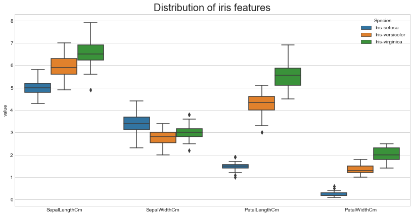

We can see that distribution for petal length and width are quite different for the 3 different species, more specifically for Iris-setosa which is smaller. Sepal features bring "less" information on how to make distinction between the species.

Another way to visualize distributions is to use [histograms](https://seaborn.pydata.org/generated/seaborn.distplot.html#seaborn.distplot) layout in a [facet grid](https://seaborn.pydata.org/generated/seaborn.FacetGrid.html#seaborn.FacetGrid):

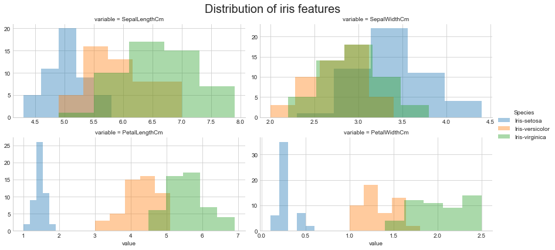

From the above plot, we confirm the difference of Iris-setosa for petal features.

We can figure out if features are correlated using a [pair plot](https://seaborn.pydata.org/generated/seaborn.pairplot.html#seaborn.pairplot):

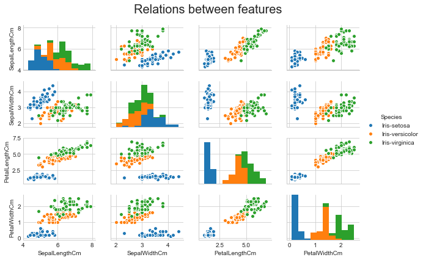

Sepal length is correlated (linearly) with sepal width. It is also correlated with petal length and width except for Iris-setosa. Similarly petal length and width are correlated, except for Iris-setosa.

## High-dimensional data visualization

Visualization of high-dimensional data is a challenge. Both pandas and scikit-learn bring options to the table.

The [Andrews curves](https://en.wikipedia.org/wiki/Andrews_plot) is a technique using values of features to feed a Fourier series implemented in [pandas](https://pandas.pydata.org/pandas-docs/stable/visualization.html#andrews-curves). Each sample in the dataset is then represented by a curve:

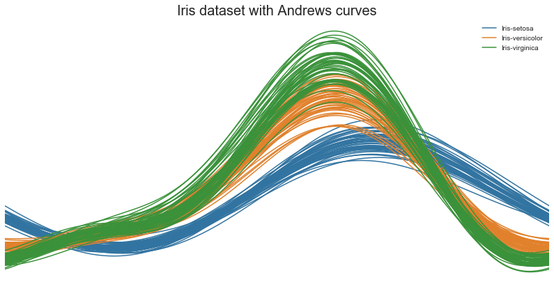

Once again, we can see that Iris-setosa clearly stands out again other species of Iris.

Another way to visualize the dataset is to used samples projection on 2D space techniques. [Scikit-learn](http://scikit-learn.org/stable/modules/manifold.html#manifold-learning) comes with manifold techniques, for example t-distributed Stochastic Neighbor Embedding (t-SNE). This method may be computationally expensive in very high-dimension spaces.

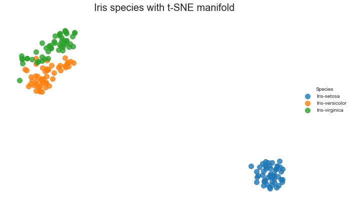

For more information on t-SNE check this [video](https://www.youtube.com/watch?v=NEaUSP4YerM).

## Dimensionality reduction

For such a simple problem (4 features), it is not necessary to reduce dimensionality for training an algorithm. However, it will come in handy to visualize the boundaries created by our decision tree classifier. We are going to keep only two dimensions for the sake of visualization simplicity. We will use a principal component analysis decomposition (PCA) from [sklearn](http://scikit-learn.org/stable/modules/generated/sklearn.decomposition.PCA.html#sklearn.decomposition.PCA) package.

After PCA algorithm has been applied, we can see on this reduced dimension space that Iris-setosa is pretty easy to identify. The boundary between Iris-versicolor and Iris-virginica is less obvious:

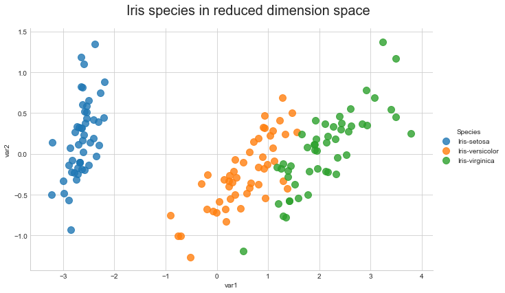

## What is machine learning ?

[figure not shown]

Source: https://www.saagie.com/fr/blog/machine-learning-pour-les-grand-meres

### Supervised Learning:

[figure not shown]

**Classification**: what is the type ?

**Regression**: what is the value ?

Source: https://medium.com/@heyozramos/regression-vs-classification-86d73c281c5e

### Our problem statement (supervised classification):

Given measures of Iris, what species is that ?

### Methodology

- Use a subset of dataset to **train** an algorithm
- Use the remaining subset to **test** algorithm

## Modelling in reduced space

In this section, we are going to train a [decision tree classifier](http://scikit-learn.org/stable/modules/generated/sklearn.tree.DecisionTreeClassifier.html). First wee need to split the dataset into training and testing datasets. We will train the algorithm in the reduced space that we have created above with PCA.

### Split training and testing dataset

We use 30% percent of dataset for test. I am using StratifiedShuffleSplit to keep the same proportion for each species in the training and testing datasets.

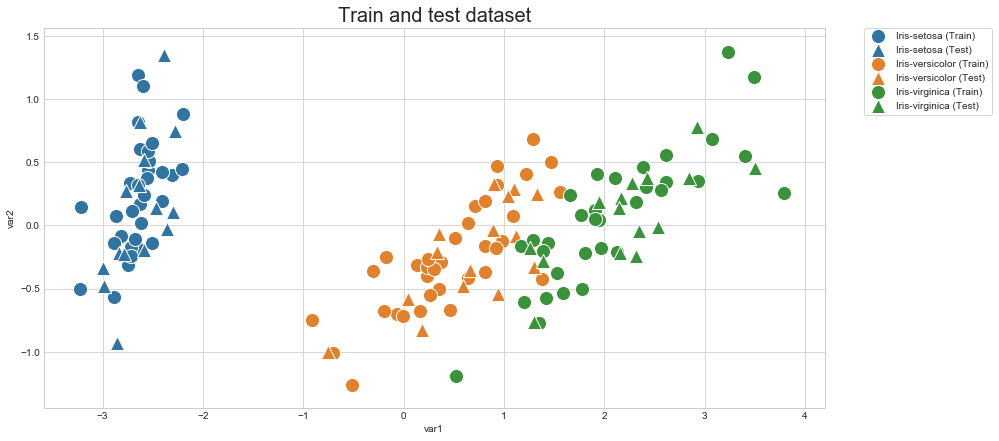

We can see that for each species, test samples have been randomized to cover the space occupied by that species.

### Train a decision tree

We are going to make the following assumption: the dataset is linearly separable. We then restrict the algorithm to only draws a very simple boundary. We can achieve this by limiting the maximum depth of decision tree to 1.

A linear boundary (background color) is calculated by the algorithm, which enables to identify Iris-setosa but not the other species:

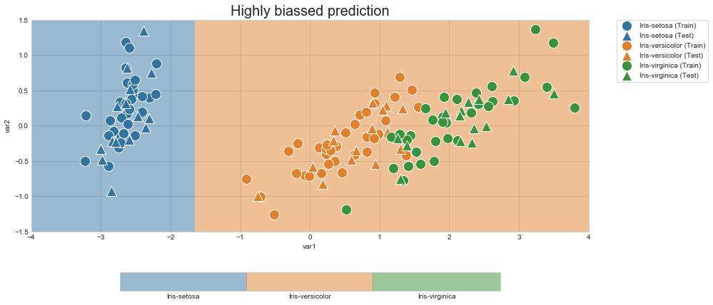

Now reduce the bias by increasing the maximum depth of decision tree to 2. The algorithms does a better job but may still be improved:

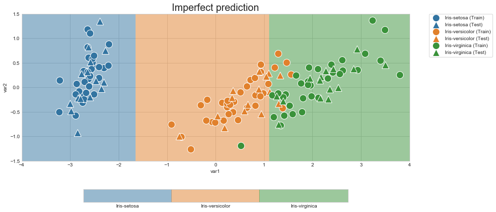

Increasing the maximum depth to 4 shows very interesting results even if few samples are incorrectly predicted:

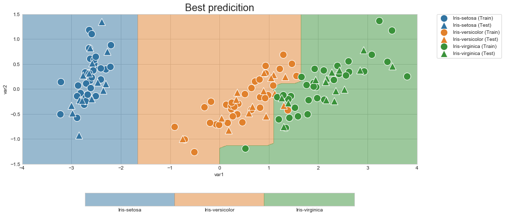

Increasing the maximum depth to 6 shows that decision tree tries to get the previously incorrectly predicted samples. This increases the variance of the model, it becomes very sensible to "exceptional" values. This is a situation of over-fitting that should be avoided:

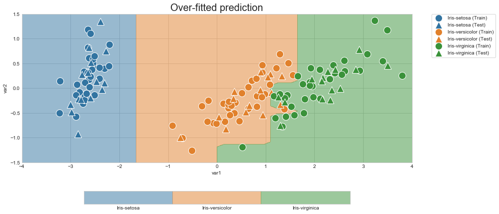

A decision tree with a maximum depth of 4 is probably the best trade-off between:

- **bias**: errors from initial assumptions in algorithm
- **variance**: errors due to sensitivity to small fluctuations in training dataset

A good predictive model has low bias and low variance.

Here is our decision trained tree:

[figure not shown]

Another way to measure accuracy of a predictive model is to use metrics:

- **precision**: prediction is consistent with the actual class of test sample
- **recall**: capability to correctly predict all items of a given class
- **fscore**: averaged score between precision and recall

| Species | fscore | precision | recall |
| --- | --- | --- | --- |
| Iris-setosa | 1.000000 | 1.0000 | 1.000000 |
| Iris-versicolor | 0.965517 | 1.0000 | 0.933333 |
| Iris-virginica | 0.967742 | 0.9375 | 1.000000 |

Here, we have one Iris-versicolor which has been predicted as a Iris-virginica. This decreases the **precision** of Iris-virginica and the **recall** of Iris-versicolor.

## Conclusion

- pandas and seaborn provides usefull and easy-to-use capabilities to **see** the data, even in high-dimensions.
- Tempted by marchine learning ? Start with **decision trees** and avoid complex alternatives (neural networks...).
- **Always** keep samples to test accurary of your predictive model.
- Consider **dimension reduction** to better understand the behavior of your predictive model.
- Tune parameters to reach a **low-bias** and a **low-variance** model.
- Someone claims he has incredible predictive model ? Ask he/she the **precision** and the **recall** scores on the **test** samples, just in case...